# SOC722 Exercise Week 2-2

## 3.2.5.6

> Does it matter what order you used `filter()` and `arrange()` if you’re using both? Why/why not? Think about the results and how much work the functions would have to do.

```r
flights |>
  filter(year == 2013) |>
  arrange(distance)
```

```
# A tibble: 336,776 × 19
    year month   day dep_time sched_dep_time dep_delay arr_time sched_arr_time
   <int> <int> <int>    <int>          <int>     <dbl>    <int>          <int>
 1  2013     7    27       NA            106        NA       NA            245
 2  2013     1     3     2127           2129        -2     2222           2224
 3  2013     1     4     1240           1200        40     1333           1306
 4  2013     1     4     1829           1615       134     1937           1721
 5  2013     1     4     2128           2129        -1     2218           2224
 6  2013     1     5     1155           1200        -5     1241           1306
 7  2013     1     6     2125           2129        -4     2224           2224
 8  2013     1     7     2124           2129        -5     2212           2224
 9  2013     1     8     2127           2130        -3     2304           2225
10  2013     1     9     2126           2129        -3     2217           2224
# ℹ 336,766 more rows
# ℹ 11 more variables: arr_delay <dbl>, carrier <chr>, flight <int>,
#   tailnum <chr>, origin <chr>, dest <chr>, air_time <dbl>, distance <dbl>,
#   hour <dbl>, minute <dbl>, time_hour <dttm>
```

```r
flights |>
  arrange(distance) |>
  filter(year == 2013)
```

```
# A tibble: 336,776 × 19
    year month   day dep_time sched_dep_time dep_delay arr_time sched_arr_time
   <int> <int> <int>    <int>          <int>     <dbl>    <int>          <int>
 1  2013     7    27       NA            106        NA       NA            245
 2  2013     1     3     2127           2129        -2     2222           2224
 3  2013     1     4     1240           1200        40     1333           1306
 4  2013     1     4     1829           1615       134     1937           1721
 5  2013     1     4     2128           2129        -1     2218           2224
 6  2013     1     5     1155           1200        -5     1241           1306
 7  2013     1     6     2125           2129        -4     2224           2224
 8  2013     1     7     2124           2129        -5     2212           2224
 9  2013     1     8     2127           2130        -3     2304           2225
10  2013     1     9     2126           2129        -3     2217           2224
# ℹ 336,766 more rows
# ℹ 11 more variables: arr_delay <dbl>, carrier <chr>, flight <int>,
#   tailnum <chr>, origin <chr>, dest <chr>, air_time <dbl>, distance <dbl>,
#   hour <dbl>, minute <dbl>, time_hour <dttm>
```

- No, the order of using `filter()` and `arrange()` does not matter. Because `filter()` does not reply on row order.

# Exercises 3.3.5

## 3.3.5.1

> Compare `dep_time`, `sched_dep_time`, and `dep_delay`. How would you expect those three numbers to be related?

```r
flights |>
  select(dep_time, sched_dep_time, dep_delay)
```

```
# A tibble: 336,776 × 3
   dep_time sched_dep_time dep_delay
      <int>          <int>     <dbl>
 1      517            515         2
 2      533            529         4
 3      542            540         2
 4      544            545        -1
 5      554            600        -6
 6      554            558        -4
 7      555            600        -5
 8      557            600        -3
 9      557            600        -3
10      558            600        -2
# ℹ 336,766 more rows
```

- `dep_delay` = `dep_time` - `sched_dep_time`

## 3.3.5.2

> Brainstorm as many ways as possible to select `dep_time`, `dep_delay`, `arr_time`, and `arr_delay` from `flights`.

```r
flights |>
  select(dep_time, dep_delay, arr_time, arr_delay)
```

```
# A tibble: 336,776 × 4
   dep_time dep_delay arr_time arr_delay
      <int>     <dbl>    <int>     <dbl>
 1      517         2      830        11
 2      533         4      850        20
 3      542         2      923        33
 4      544        -1     1004       -18
 5      554        -6      812       -25
 6      554        -4      740        12
 7      555        -5      913        19
 8      557        -3      709       -14
 9      557        -3      838        -8
10      558        -2      753         8
# ℹ 336,766 more rows
```

```r
flights |>
  select(starts_with(c("dep", "arr")))
```

```
# A tibble: 336,776 × 4
   dep_time dep_delay arr_time arr_delay
      <int>     <dbl>    <int>     <dbl>
 1      517         2      830        11
 2      533         4      850        20
 3      542         2      923        33
 4      544        -1     1004       -18
 5      554        -6      812       -25
 6      554        -4      740        12
 7      555        -5      913        19
 8      557        -3      709       -14
 9      557        -3      838        -8
10      558        -2      753         8
# ℹ 336,766 more rows
```

```r
flights |>
  select(dep_time:arr_delay & !c(sched_arr_time, sched_dep_time))
```

```
# A tibble: 336,776 × 4
   dep_time dep_delay arr_time arr_delay
      <int>     <dbl>    <int>     <dbl>
 1      517         2      830        11
 2      533         4      850        20
 3      542         2      923        33
 4      544        -1     1004       -18
 5      554        -6      812       -25
 6      554        -4      740        12
 7      555        -5      913        19
 8      557        -3      709       -14
 9      557        -3      838        -8
10      558        -2      753         8
# ℹ 336,766 more rows
```

## 3.3.5.3

> What happens if you specify the name of the same variable multiple times in a `select()` call?

```r
flights |>
  select(dep_time, dep_time, dep_time)
```

```
# A tibble: 336,776 × 1
   dep_time
      <int>
 1      517
 2      533
 3      542
 4      544
 5      554
 6      554
 7      555
 8      557
 9      557
10      558
# ℹ 336,766 more rows
```

- Only one variable is selected.

## 3.3.5.4

> What does the `any_of()` function do? Why might it be helpful in conjunction with this vector?

> `variables <- c("year", "month", "day", "dep_delay", "arr_delay")`

```r
variables <- c("year", "month", "day", "dep_delay", "arr_delay")

flights |>
  select(any_of(variables))
```

```
# A tibble: 336,776 × 5
    year month   day dep_delay arr_delay
   <int> <int> <int>     <dbl>     <dbl>
 1  2013     1     1         2        11
 2  2013     1     1         4        20
 3  2013     1     1         2        33
 4  2013     1     1        -1       -18
 5  2013     1     1        -6       -25
 6  2013     1     1        -4        12
 7  2013     1     1        -5        19
 8  2013     1     1        -3       -14
 9  2013     1     1        -3        -8
10  2013     1     1        -2         8
# ℹ 336,766 more rows
```

- `any_of()` selects variables in a character vector. It explicitly specifies the name of variables in a separated command line.

## 3.3.5.5

> Does the result of running the following code surprise you? How do the select helpers deal with upper and lower case by default? How can you change that default?

> `flights |> select(contains("TIME"))`

```r
flights |>
  select(contains("TIME"))
```

```
# A tibble: 336,776 × 6
   dep_time sched_dep_time arr_time sched_arr_time air_time time_hour
      <int>          <int>    <int>          <int>    <dbl> <dttm>
 1      517            515      830            819      227 2013-01-01 05:00:00
 2      533            529      850            830      227 2013-01-01 05:00:00
 3      542            540      923            850      160 2013-01-01 05:00:00
 4      544            545     1004           1022      183 2013-01-01 05:00:00
 5      554            600      812            837      116 2013-01-01 06:00:00
 6      554            558      740            728      150 2013-01-01 05:00:00
 7      555            600      913            854      158 2013-01-01 06:00:00
 8      557            600      709            723       53 2013-01-01 06:00:00
 9      557            600      838            846      140 2013-01-01 06:00:00
10      558            600      753            745      138 2013-01-01 06:00:00
# ℹ 336,766 more rows
```

- By default, `contains()` ignores case (`ignore.case = TRUE`).

```r
## Specify case sensitive
flights |>
  select(contains("TIME", ignore.case = FALSE))
```

```
# A tibble: 336,776 × 0
```

## 3.3.5.6

> Rename `air_time` to `air_time_min` to indicate units of measurement and move it to the beginning of the data frame.

```r
flights |>
  rename(air_time_min = air_time) |>
  relocate(air_time_min)
```

```
# A tibble: 336,776 × 19
   air_time_min  year month   day dep_time sched_dep_time dep_delay arr_time
          <dbl> <int> <int> <int>    <int>          <int>     <dbl>    <int>
 1          227  2013     1     1      517            515         2      830
 2          227  2013     1     1      533            529         4      850
 3          160  2013     1     1      542            540         2      923
 4          183  2013     1     1      544            545        -1     1004
 5          116  2013     1     1      554            600        -6      812
 6          150  2013     1     1      554            558        -4      740
 7          158  2013     1     1      555            600        -5      913
 8           53  2013     1     1      557            600        -3      709
 9          140  2013     1     1      557            600        -3      838
10          138  2013     1     1      558            600        -2      753
# ℹ 336,766 more rows
# ℹ 11 more variables: sched_arr_time <int>, arr_delay <dbl>, carrier <chr>,
#   flight <int>, tailnum <chr>, origin <chr>, dest <chr>, distance <dbl>,
#   hour <dbl>, minute <dbl>, time_hour <dttm>
```

## 3.3.5.7

> Why doesn’t the following work, and what does the error mean?

> ```
> flights |>
>  select(tailnum) |>
>  arrange(arr_delay)
> #> Error in `arrange()`:
> #> ℹ In argument: `..1 = arr_delay`.
> #> Caused by error:
> #> ! object 'arr_delay' not found
> ```

```r
flights |>
  select(tailnum) |>
  arrange(arr_delay)
```

```
Error in `arrange()`:
ℹ In argument: `..1 = arr_delay`.
Caused by error:
! object 'arr_delay' not found
```

- Because after `select(tailnum)`, only one column `tailnum` is left. In the next step `arrange(arr_delay)`, R cannot find a column named `arr_delay`.

# Exercises 3.5.7

## 3.5.7.1

> Which carrier has the worst average delays? Challenge: can you disentangle the effects of bad airports vs. bad carriers? Why/why not? (Hint: think about `flights |> group_by(carrier, dest) |> summarize(n())`)

```r
flights |>
  group_by(carrier) |>
  summarize(
    avg_dep_delay_carrier = mean(dep_delay, na.rm = TRUE)
  ) |>
  arrange(desc(avg_dep_delay_carrier))
```

```
# A tibble: 16 × 2
   carrier avg_dep_delay_carrier
   <chr>                   <dbl>
 1 F9                      20.2
 2 EV                      20.0
 3 YV                      19.0
 4 FL                      18.7
 5 WN                      17.7
 6 9E                      16.7
 7 B6                      13.0
 8 VX                      12.9
 9 OO                      12.6
10 UA                      12.1
11 MQ                      10.6
12 DL                       9.26
13 AA                       8.59
14 AS                       5.80
15 HA                       4.90
16 US                       3.78
```

- `F9` Frontier Airlines has the worst average departure delays.

```r
flights |>
  group_by(carrier, dest) |>
  summarize(
    n = n()
  ) |>
  filter(carrier == "F9")
```

```
# A tibble: 1 × 3
# Groups:   carrier [1]
  carrier dest      n
  <chr>   <chr> <int>
1 F9      DEN     685
```

```r
flights |>
  group_by(dest) |>
  summarize(
    avg_dep_delay_dest = mean(dep_delay, na.rm = TRUE)
  ) |>
    arrange(desc(avg_dep_delay_dest))
```

```
# A tibble: 105 × 2
   dest  avg_dep_delay_dest
   <chr>              <dbl>
 1 CAE                 35.6
 2 TUL                 34.9
 3 OKC                 30.6
 4 BHM                 29.7
 5 TYS                 28.5
 6 JAC                 26.5
 7 DSM                 26.2
 8 RIC                 23.6
 9 ALB                 23.6
10 MSN                 23.6
# ℹ 95 more rows
```

- We cannot disentangle the effects of bad airports vs. bad carriers because Frontier Airlines has only one destination `DEN`, but `DEN` is not among the worst destinations of departure delays.

### 3.5.7.2

> Find the flights that are most delayed upon departure to each destination.

```r
flights |>
  group_by(dest) |>
  slice_max(dep_delay) |>
  relocate(carrier, flight, dep_delay, dest) |>
  arrange(desc(dep_delay))
```

```
# A tibble: 105 × 19
# Groups:   dest [105]
   carrier flight dep_delay dest   year month   day dep_time sched_dep_time
   <chr>    <int>     <dbl> <chr> <int> <int> <int>    <int>          <int>
 1 HA          51      1301 HNL    2013     1     9      641            900
 2 MQ        3535      1137 CMH    2013     6    15     1432           1935
 3 MQ        3695      1126 ORD    2013     1    10     1121           1635
 4 AA         177      1014 SFO    2013     9    20     1139           1845
 5 MQ        3075      1005 CVG    2013     7    22      845           1600
 6 DL        2391       960 TPA    2013     4    10     1100           1900
 7 DL        2119       911 MSP    2013     3    17     2321            810
 8 DL        2007       899 PDX    2013     6    27      959           1900
 9 DL        2047       898 ATL    2013     7    22     2257            759
10 AA         172       896 MIA    2013    12     5      756           1700
# ℹ 95 more rows
# ℹ 10 more variables: arr_time <int>, sched_arr_time <int>, arr_delay <dbl>,
#   tailnum <chr>, origin <chr>, air_time <dbl>, distance <dbl>, hour <dbl>,
#   minute <dbl>, time_hour <dttm>
```

### 3.5.7.3

> How do delays vary over the course of the day? Illustrate your answer with a plot.

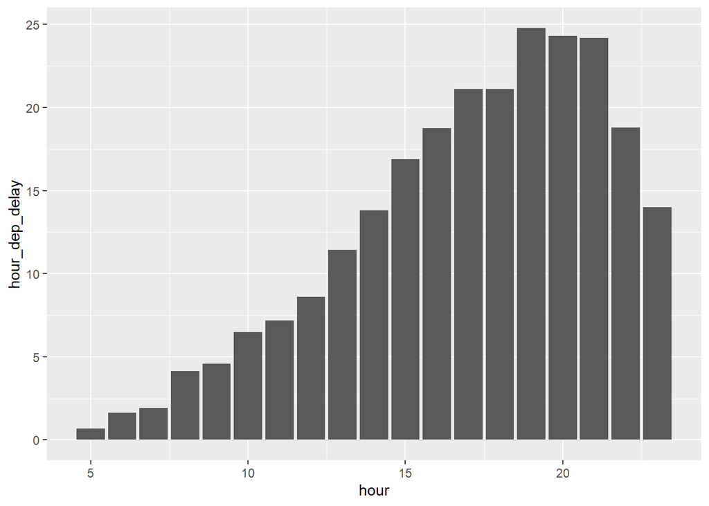

```r
flights |>
  group_by(hour) |>
  summarize(
    hour_dep_delay = mean(dep_delay, na.rm = TRUE)
  ) |>
ggplot(mapping =
         aes(x = hour, y = hour_dep_delay)) +
  geom_col()
```

### 3.5.7.4

> What happens if you supply a negative `n` to `slice_min()` and friends?

```r
flights |>
  group_by(carrier) |>
  slice_min(dep_delay, n = 1) |>
  arrange(dep_delay)
```

```
# A tibble: 19 × 19
# Groups:   carrier [16]
    year month   day dep_time sched_dep_time dep_delay arr_time sched_arr_time
   <int> <int> <int>    <int>          <int>     <dbl>    <int>          <int>
 1  2013    12     7     2040           2123       -43       40           2352
 2  2013     2     3     2022           2055       -33     2240           2338
 3  2013    11    10     1408           1440       -32     1549           1559
 4  2013     1    29     1703           1730       -27     1947           1957
 5  2013     8     9      729            755       -26     1002            955
 6  2013     3     2     1431           1455       -24     1601           1631
 7  2013     5    14      914            938       -24     1143           1204
 8  2013     9    18     1631           1655       -24     1812           1845
 9  2013     1    12     1354           1416       -22     1606           1650
10  2013     1    20      704            725       -21     1025           1035
11  2013    10    22      700            720       -20     1002           1000
12  2013     9    21     1240           1300       -20     1402           1434
13  2013    12    11      710            730       -20     1039           1105
14  2013     6     1      610            629       -19      740            820
15  2013    11    26      944           1000       -16     1539           1555
16  2013    11     5     1132           1148       -16     1343           1404
17  2013     8    26     1719           1735       -16     1911           1938
18  2013     9    24     1751           1805       -14     1937           1953
19  2013     1    20     2047           2100       -13     2211           2225
# ℹ 11 more variables: arr_delay <dbl>, carrier <chr>, flight <int>,
#   tailnum <chr>, origin <chr>, dest <chr>, air_time <dbl>, distance <dbl>,
#   hour <dbl>, minute <dbl>, time_hour <dttm>
```

```r
flights |>
  group_by(carrier) |>
  slice_min(dep_delay, n = -1) |>
  arrange(dep_delay)
```

```
# A tibble: 336,775 × 19
# Groups:   carrier [16]
    year month   day dep_time sched_dep_time dep_delay arr_time sched_arr_time
   <int> <int> <int>    <int>          <int>     <dbl>    <int>          <int>
 1  2013    12     7     2040           2123       -43       40           2352
 2  2013     2     3     2022           2055       -33     2240           2338
 3  2013    11    10     1408           1440       -32     1549           1559
 4  2013     1    11     1900           1930       -30     2233           2243
 5  2013     1    29     1703           1730       -27     1947           1957
 6  2013     8     9      729            755       -26     1002            955
 7  2013    10    23     1907           1932       -25     2143           2143
 8  2013     3    30     2030           2055       -25     2213           2250
 9  2013     3     2     1431           1455       -24     1601           1631
10  2013     5    14      914            938       -24     1143           1204
# ℹ 336,765 more rows
# ℹ 11 more variables: arr_delay <dbl>, carrier <chr>, flight <int>,
#   tailnum <chr>, origin <chr>, dest <chr>, air_time <dbl>, distance <dbl>,
#   hour <dbl>, minute <dbl>, time_hour <dttm>
```

```r
flights |>
  group_by(carrier) |>
  slice_max(dep_delay, n = 1) |>
  arrange(desc(dep_delay))
```

```
# A tibble: 16 × 19
# Groups:   carrier [16]
    year month   day dep_time sched_dep_time dep_delay arr_time sched_arr_time
   <int> <int> <int>    <int>          <int>     <dbl>    <int>          <int>
 1  2013     1     9      641            900      1301     1242           1530
 2  2013     6    15     1432           1935      1137     1607           2120
 3  2013     9    20     1139           1845      1014     1457           2210
 4  2013     4    10     1100           1900       960     1342           2211
 5  2013     2    10     2243            830       853      100           1106
 6  2013     2    16      757           1930       747     1013           2149
 7  2013     7     7     2123           1030       653       17           1345
 8  2013     9    12       12           1410       602      207           1635
 9  2013    12     5     1955           1047       548     2143           1245
10  2013     1    16     1622            800       502     1911           1054
11  2013     6    28      125           1705       500      316           1911
12  2013     7    26     2345           1542       483      104           1729
13  2013     5    11     2316           1525       471       43           1710
14  2013    10    22     1812           1145       387     2017           1356
15  2013     5    23     2205           1820       225       41           2133
16  2013     8    28     2039           1805       154     2213           1953
# ℹ 11 more variables: arr_delay <dbl>, carrier <chr>, flight <int>,
#   tailnum <chr>, origin <chr>, dest <chr>, air_time <dbl>, distance <dbl>,
#   hour <dbl>, minute <dbl>, time_hour <dttm>
```

```r
flights |>
  group_by(carrier) |>
  slice_max(dep_delay, n = -1) |>
  arrange(desc(dep_delay))
```

```
# A tibble: 336,775 × 19
# Groups:   carrier [16]
    year month   day dep_time sched_dep_time dep_delay arr_time sched_arr_time
   <int> <int> <int>    <int>          <int>     <dbl>    <int>          <int>
 1  2013     1     9      641            900      1301     1242           1530
 2  2013     6    15     1432           1935      1137     1607           2120
 3  2013     1    10     1121           1635      1126     1239           1810
 4  2013     9    20     1139           1845      1014     1457           2210
 5  2013     7    22      845           1600      1005     1044           1815
 6  2013     4    10     1100           1900       960     1342           2211
 7  2013     3    17     2321            810       911      135           1020
 8  2013     6    27      959           1900       899     1236           2226
 9  2013     7    22     2257            759       898      121           1026
10  2013    12     5      756           1700       896     1058           2020
# ℹ 336,765 more rows
# ℹ 11 more variables: arr_delay <dbl>, carrier <chr>, flight <int>,
#   tailnum <chr>, origin <chr>, dest <chr>, air_time <dbl>, distance <dbl>,
#   hour <dbl>, minute <dbl>, time_hour <dttm>
```

### 3.5.7.5

> Explain what `count()` does in terms of the dplyr verbs you just learned. What does the sort argument to `count()` do?

```r
flights |>
  count(carrier, sort = TRUE)
```

```
# A tibble: 16 × 2
   carrier     n
   <chr>   <int>
 1 UA      58665
 2 B6      54635
 3 EV      54173
 4 DL      48110
 5 AA      32729
 6 MQ      26397
 7 US      20536
 8 9E      18460
 9 WN      12275
10 VX       5162
11 FL       3260
12 AS        714
13 F9        685
14 YV        601
15 HA        342
16 OO         32
```

```r
flights |>
  group_by(carrier) |>
  summarize(n = n()) |>
  arrange(desc(n))
```

```
# A tibble: 16 × 2
   carrier     n
   <chr>   <int>
 1 UA      58665
 2 B6      54635
 3 EV      54173
 4 DL      48110
 5 AA      32729
 6 MQ      26397
 7 US      20536
 8 9E      18460
 9 WN      12275
10 VX       5162
11 FL       3260
12 AS        714
13 F9        685
14 YV        601
15 HA        342
16 OO         32
```

- `count()` functions similar to `group_by() |> summarize(n = n())`, but the tibble is not grouped. `sort` is similar to `arrange(desc())`

### 3.5.7.6

> Suppose we have the following tiny data frame:

> ```
> df <- tibble(
>  x = 1:5,
>  y = c("a", "b", "a", "a", "b"),
>  z = c("K", "K", "L", "L", "K")
> )
> ```

#### a

> Write down what you think the output will look like, then check if you were correct, and describe what `group_by()` does.

> `df |> group_by(y)`

| x | y | z |
| --- | --- | --- |
| 1 | a | K |
| 2 | b | K |
| 3 | a | L |
| 4 | a | L |
| 5 | b | K |

```r
df <- tibble(
 x = 1:5,
 y = c("a", "b", "a", "a", "b"),
 z = c("K", "K", "L", "L", "K")
)
df
```

```
# A tibble: 5 × 3
      x y     z
  <int> <chr> <chr>
1     1 a     K
2     2 b     K
3     3 a     L
4     4 a     L
5     5 b     K
```

```r
df |>
  group_by(y)
```

```
# A tibble: 5 × 3
# Groups:   y [2]
      x y     z
  <int> <chr> <chr>
1     1 a     K
2     2 b     K
3     3 a     L
4     4 a     L
5     5 b     K
```

- `df` is grouped by `y`.

#### b

> Write down what you think the output will look like, then check if you were correct, and describe what `arrange()` does. Also, comment on how it’s different from the `group_by()` in part (a).

> `df |> arrange(y)`

| x | y | z |
| --- | --- | --- |
| 1 | a | K |
| 3 | a | L |
| 4 | a | L |
| 2 | b | K |
| 5 | b | K |

```r
df |>
  arrange(y)
```

```
# A tibble: 5 × 3
      x y     z
  <int> <chr> <chr>
1     1 a     K
2     3 a     L
3     4 a     L
4     2 b     K
5     5 b     K
```

- `df` is arranged by the alphabet order of `y`. In (b), the order of rows is changed, but in (a) the order is not changed.

#### c

> Write down what you think the output will look like, then check if you were correct, and describe what the pipeline does.

> `df |> group_by(y) |> summarize(mean_x = mean(x))`

| y | mean_x |
| --- | --- |
| a | 2.67 |
| b | 3.50 |

```r
df |>
  group_by(y) |>
  summarize(mean_x = mean(x))
```

```
# A tibble: 2 × 2
  y     mean_x
  <chr>  <dbl>
1 a       2.67
2 b       3.5
```

- `df` is grouped by `y` with two groups are created. Then the mean of x in each group is calculated and saved as `mean_x`.

#### d

> Write down what you think the output will look like, then check if you were correct, and describe what the pipeline does. Then, comment on what the message says.

> ```
> df |>
> group_by(y, z) |>
> summarize(mean_x = mean(x))
> ```

| y | z | mean_x |
| --- | --- | --- |
| a | K | 1.0 |
| a | L | 3.5 |
| b | K | 3.5 |

```r
df |>
  group_by(y, z) |>
  summarize(mean_x = mean(x))
```

[output not shown]

```
# A tibble: 3 × 3
# Groups:   y [2]
  y     z     mean_x
  <chr> <chr>  <dbl>
1 a     K        1
2 a     L        3.5
3 b     K        3.5
```

#### e

> Write down what you think the output will look like, then check if you were correct, and describe what the pipeline does. How is the output different from the one in part (d)?

> ```
> df |>
>  group_by(y, z) |>
>  summarize(mean_x = mean(x), .groups = "drop")
> ```

| y | z | mean_x |
| --- | --- | --- |
| a | K | 1.0 |
| a | L | 3.5 |
| b | K | 3.5 |

```r
df |>
  group_by(y, z) |>
  summarize(mean_x = mean(x), .groups = "drop")
```

```
# A tibble: 3 × 3
  y     z     mean_x
  <chr> <chr>  <dbl>
1 a     K        1
2 a     L        3.5
3 b     K        3.5
```

#### f

> Write down what you think the outputs will look like, then check if you were correct, and describe what each pipeline does. How are the outputs of the two pipelines different?

> ```
> df |>
>  group_by(y, z) |>
>  summarize(mean_x = mean(x))
>
> df |>
>  group_by(y, z) |>
>  mutate(mean_x = mean(x))
> ```

- The first pipe:

| y | z | mean_x |
| --- | --- | --- |
| a | K | 1.0 |
| a | L | 3.5 |
| b | K | 3.5 |

- The second pipe:

| x | y | z | mean_x |
| --- | --- | --- | --- |
| 1 | a | K | 1.0 |
| 2 | b | K | 3.5 |
| 3 | a | L | 3.5 |
| 4 | a | L | 3.5 |
| 5 | b | K | 3.5 |

```r
df |>
  group_by(y, z) |>
  summarize(mean_x = mean(x))
```

[output not shown]

```
# A tibble: 3 × 3
# Groups:   y [2]
  y     z     mean_x
  <chr> <chr>  <dbl>
1 a     K        1
2 a     L        3.5
3 b     K        3.5
```

```r
df |>
  group_by(y, z) |>
  mutate(mean_x = mean(x))
```

```
# A tibble: 5 × 4
# Groups:   y, z [3]
      x y     z     mean_x
  <int> <chr> <chr>  <dbl>
1     1 a     K        1
2     2 b     K        3.5
3     3 a     L        3.5
4     4 a     L        3.5
5     5 b     K        3.5
```